# Population genetics of cichlid fish in lakes Kivu, Mweru and Victoria

Calculate $d_f$ and $d_{xy}$ in `10kb` blocks for species pairs in three lakes. Some extra plots also.

- Steps 1-5 represent our first look at the data.
- In steps 6-10, we basically started over, this time looking at $d_f$ and $d_{xy}$.
- In steps 11-13, we calculate the per-block read coverage.

### Step 1 : initialize scaffold block arrays

Continuing from the CichlidVariantCalling notebook...

- Load the VCF data using [`PyVCF`](https://github.com/jdoughertyii/PyVCF)
- Use blocks of 10kb
- Ignore contigs less than 20mb
- Load only non-heterogeneous variants

We plot the sorted contig values to show where the `20mb` cutoff falls in the distribution of scaffold sizes. For each scaffold that exceeds the size cutoff, we create an arrays with number of blocks in each scaffold. The blocks are initialized to zero.

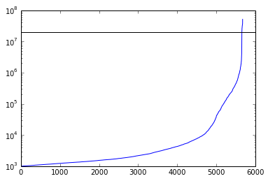

```python
%pylab inline
import vcf

block_size = 10000
size_cut   = 2e7

#vcf_reader = vcf.Reader(open('/home/russell/fish/talapia/cichlid.wgs.vcf', 'rb'))
#vcf_reader = vcf.Reader(open('/home/russell/fish/talapia/cichlid.wgs.vcf', 'rb'))
vcf_reader = vcf.Reader(open('/home/russell/fish/talapia/SNPs_only.kivu.vcf', 'rb'))
#vcf_reader = vcf.Reader(open('SNPs_only.kivu_hom.vcf.gz', 'rb'))
#vcf_reader = vcf.Reader(open('SNPs_only.mweru_hom.vcf.gz', 'rb'))

contig_lengths = {}
for contig in vcf_reader.contigs :
    length = vcf_reader.contigs[contig].length
    contig_lengths[contig] = length

plot(sorted(contig_lengths.values()))
axhline(size_cut,color='black')
semilogy()

bigcontigs = []
mysamples = {}
for name in vcf_reader.samples :
    mycontigs = {}
    for contig in vcf_reader.contigs :
        if contig_lengths[contig] > size_cut :
            if not bigcontigs.__contains__(contig) :
                bigcontigs.append(contig)
            mycontigs[contig] = { 'length' : length,
                                  'allvars': zeros(contig_lengths[contig]/block_size+1),
                                  'fixed'  : zeros(contig_lengths[contig]/block_size+1),
                                  }
    mysamples[name] = mycontigs

# 78357 vs 78584 : Serranochromis sp. “checkerboard”, Orthochromis sp. red cheek
checkerboard_vs_redcheek = {}
# 80344 vs checkmate : Paralabidochromis flavus, checkmate
flavus_vs_checkmate = {}

for contig in mycontigs.keys() :
    checkerboard_vs_redcheek[contig] = zeros(contig_lengths[contig]/block_size+1)
    flavus_vs_checkmate[contig] = zeros(contig_lengths[contig]/block_size+1)
```

### Step 2 : count the variants

For each block in each scaffold, find the number of fixed and heterozygous variants.

```python
for n,obs in enumerate(vcf_reader) :
    if n%100000 == 0 : print n
    #if n == 100 : break
    if not bigcontigs.__contains__(obs.CHROM) : continue
    if obs.is_indel : continue
    gts,calls = {},{}
    for s in obs.samples :
        calls[s.sample] = s
        if s.gt_bases :
            gts[s.sample] = sorted(s.gt_bases.split('/'))
        else :
            gts[s.sample] = None
    #if gts['78357'] == gts['78584'] \
    #    and not calls['78357'].is_het and not calls['78584'].is_het \
    #    and calls['78357'].is_variant and calls['78584'].is_variant \
    #    and calls['78357'].called and calls['78584'].called :
    #        flavus_vs_checkmate[obs.CHROM]
    for s in obs.samples :
        #if s.is_variant and s.called and not s.is_het :
        if s.is_variant and s.called :
            #print s.sample, s.site.QUAL, s.site.POS, s.gt_alleles
            if not s.is_het :
                mysamples[s.sample][obs.CHROM]['fixed'][s.site.POS/block_size] \
                    = mysamples[s.sample][obs.CHROM]['fixed'][s.site.POS/block_size] + 1

            mysamples[s.sample][obs.CHROM]['allvars'][s.site.POS/block_size] \
                = mysamples[s.sample][obs.CHROM]['allvars'][s.site.POS/block_size] + 1
```

```
0
100000
200000
300000
400000
```

### Step 3 : checkpoint, resume

```python
import cPickle

cPickle.dump( mysamples, open('victoria_10kb.pickle','wb') )
```

```python
import cPickle

mysamples = cPickle.load( open('victoria_10kb.pickle','r') )
```

### Step 4 : make some smoothed variant distributions for visualization

- Apply Wiener-Komolgerov filter
- Convolve with a blackman window
- Search for local maxima

```python
from scipy.signal import blackman, wiener, convolve, find_peaks_cwt
from pique import peak

window = blackman( 100 )
window = window / sum(window)

maxsnps = 0
for n,c in enumerate(bigcontigs) :
    for s in vcf_reader.samples :
        data = wiener( mysamples[s][c]['allvars'], mysize=50 )
        data = convolve( data, window, mode='same' )
        if max(mysamples[s][c]['allvars']) > maxsnps : maxsnps = max(mysamples[s][c]['allvars'])
        maxtab, mintab = peak.peakdet(data, 0.5)
        #maxtab = find_peaks_cwt( mysamples[s][c]['snps'], arange(10,100) )
        mysamples[s][c]['wiener'] = data
        mysamples[s][c]['maxima'] = maxtab
        mysamples[s][c]['minima'] = mintab
        mysamples[s][c]['total']  = sum(mysamples[s][c]['allvars'])
```

### Step 5 : visualize the variant distributions

- Plot filtered variant densities by chromosome
- Mark local maxima

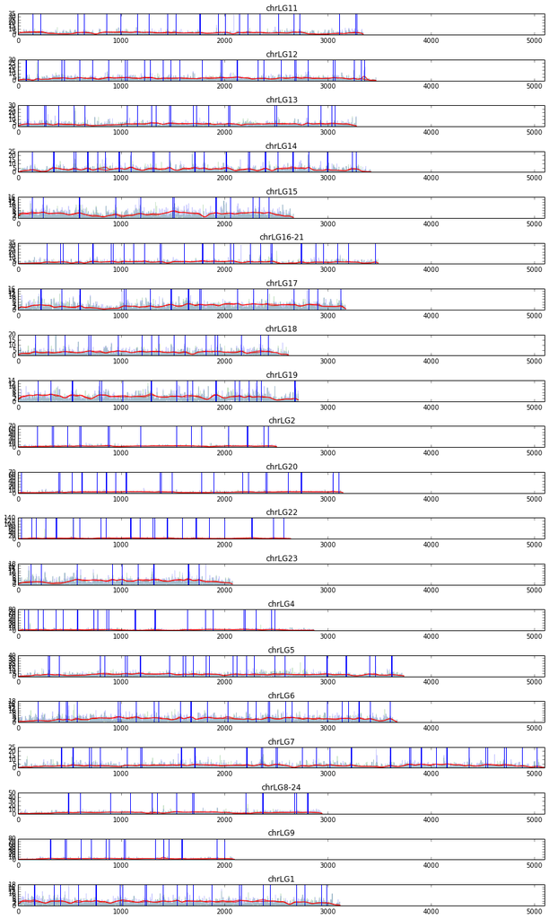

```python
figsize(12,20)

for n,c in enumerate(bigcontigs) :
    subplot(len(bigcontigs),1,n)
    for s in mysamples.keys() :
        plot(mysamples[s][c]['fixed'],alpha=.2)
        plot(mysamples[s][c]['wiener'],color='red')
        for maximum in mysamples[s][c]['maxima'] :
            x,y = maximum
            axvline(x)
        xlim(0,max(contig_lengths.values())/block_size)
        #ylim(0,maxsnps)
        title(c)
tight_layout()
```

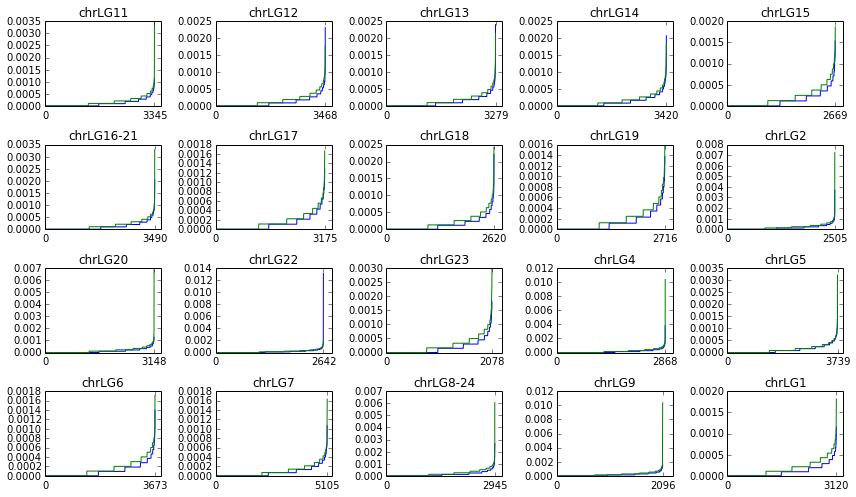

```python
figsize(12,7)

for n,c in enumerate(bigcontigs) :
    subplot(4,5,n)
    for s in vcf_reader.samples :
        plot(sorted(mysamples[s][c]['fixed'])/mysamples[s][c]['total'])
        xticks([0,len(mysamples[s][c]['fixed'])])
        xlim([0,len(mysamples[s][c]['fixed'])+200])
        title(c)
tight_layout()
```

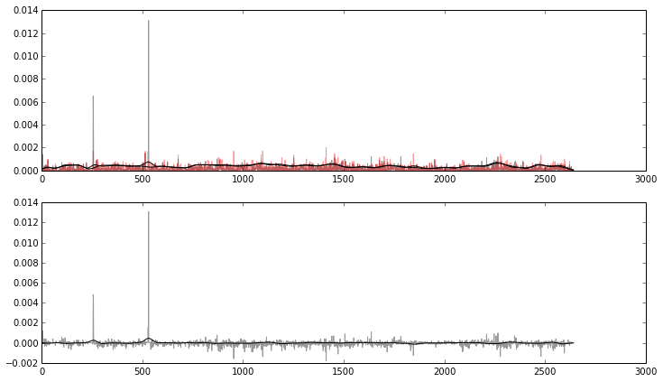

```python
#80344 vs checkmate
#78357 vs 78584

#s1,s2 = mysamples.keys()[4], mysamples.keys()[-1]
#s1,s2 = "80344", "checkmate"
s1,s2 = "64571", "64253"
c = bigcontigs[12]
subplot(2,1,1)
plot(mysamples[s1][c]['fixed']/mysamples[s1][c]['total'], color='black', alpha=0.4)
plot(mysamples[s2][c]['fixed']/mysamples[s2][c]['total'], color='red', alpha=0.4)
plot(mysamples[s1][c]['wiener']/mysamples[s1][c]['total'], color='black')
plot(mysamples[s2][c]['wiener']/mysamples[s2][c]['total'], color='black')
subplot(2,1,2)
plot(mysamples[s1][c]['fixed']/mysamples[s1][c]['total']-mysamples[s2][c]['fixed']/mysamples[s2][c]['total'], color='black', alpha =0.4)
plot(mysamples[s1][c]['wiener']/mysamples[s1][c]['total']-mysamples[s2][c]['wiener']/mysamples[s2][c]['total'], color='black')
```

### Step 6 : Calculate $d_f$ and $d_{xy}$

We basically start over here.

```python
import numpy
import vcf
import distance
import csv

block_size = 10000
size_cut   = 2e7

#vcf_reader = vcf.Reader(open('/home/russell/fish/talapia/SNPs_only.kivu.vcf', 'rb'))
#vcf_reader = vcf.Reader(open('/home/russell/fish/talapia/SNPs_only.victora.vcf', 'rb'))
vcf_reader = vcf.Reader(open('/home/russell/fish/talapia/SNPs_only.mweru.vcf', 'rb'))

contig_lengths = {}
for contig in vcf_reader.contigs :
    length = vcf_reader.contigs[contig].length
    contig_lengths[contig] = length

#plot(sorted(contig_lengths.values()))
#axhline(size_cut,color='black')
#semilogy()

bigcontigs = []
mycontigs = {}
for contig in vcf_reader.contigs :
    if contig_lengths[contig] > size_cut :
        if not bigcontigs.__contains__(contig) :
            bigcontigs.append(contig)
        mycontigs[contig] = { 'length' : length, 'df'  : numpy.zeros(contig_lengths[contig]/block_size+1),
                              'length' : length, 'dxy' : numpy.zeros(contig_lengths[contig]/block_size+1) }

for n,obs in enumerate(vcf_reader) :
    if n%100000 == 0 : print n
    #if n == 100 : break
    if not bigcontigs.__contains__(obs.CHROM) : continue
    if obs.is_indel : continue
    samp1 = obs.samples[0].gt_bases
    samp2 = obs.samples[1].gt_bases
    if samp1 is None or samp2 is None : continue
    samp1 = ''.join(sorted(samp1))
    samp2 = ''.join(sorted(samp2))
    sampdist = distance.hamming(samp1,samp2)
    mycontigs[obs.CHROM]['dxy'][obs.POS/block_size] = mycontigs[obs.CHROM]['dxy'][obs.POS/block_size] + sampdist
    if not obs.samples[0].is_het and not obs.samples[1].is_het and sampdist == 2 :
        #print obs.CHROM, obs.POS/block_size, sampdist
        mycontigs[obs.CHROM]['df'][obs.POS/block_size] = mycontigs[obs.CHROM]['df'][obs.POS/block_size] + 1
```

[output not shown]

### Step 7 : checkpoint

```python
import pickle

pickle.dump(mycontigs, open('mweru_df_dxy.pickle', 'w'))
```

### Step 8 : visualize $d_f$ and $d_{xy}$ distributions

Here, we plot $d_f$ and $d_{xy}$ in each lake for chromosome. Victoria is in black, Kivu is in red, and Mweru is in green. Smoothed trends are plotted in saturated colors, values for individual `10kb` blocks shown in lighter colors.

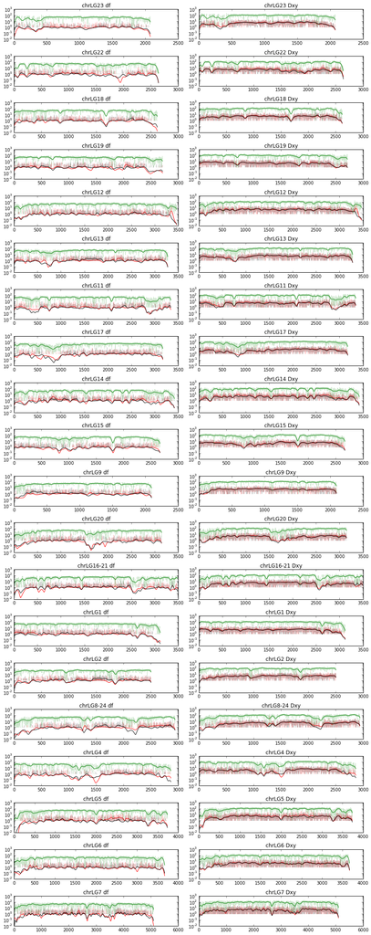

```python
from scipy.signal import blackman, wiener, convolve, find_peaks_cwt
from pique import peak

figsize(12,30)

window = blackman( 100 )
window = window / sum(window)

kivu     = pickle.load(open('kivu_df_dxy.pickle'))
victoria = pickle.load(open('victoria_df_dxy.pickle'))
mweru    = pickle.load(open('mweru_df_dxy.pickle'))

for n,contig in enumerate(mycontigs.keys()) :
    subplot(len(mycontigs.keys()),2,n*2+1)
    for lake,color in ( (kivu,'red'), (victoria,'black'), (mweru,'green')) :
        data = wiener( lake[contig]['df'], mysize=50 )
        data = convolve( data, window, mode='same' )
        plot(lake[contig]['df'],color=color,alpha=0.2)
        plot(data,color=color)
        title(contig + ' ' + 'df')
        ylim(0.01,10e2)
        semilogy()
    subplot(len(mycontigs.keys()),2,n*2+2)
    for lake,color in ( (kivu,'red'), (victoria,'black'), (mweru,'green')) :
        data = wiener( lake[contig]['dxy'], mysize=50 )
        data = convolve( data, window, mode='same' )
        plot(lake[contig]['dxy'],color=color,alpha=0.2)
        plot(data,color=color)
        title(contig + ' ' + 'Dxy')
        ylim(0.01,10e2)
        semilogy()
tight_layout()

savefig( 'df_dxy.png', format='png', dpi=100 )
savefig( 'df_dxy.pdf', format='pdf', dpi=100 )
```

### Step 9 : $d_f$ **vs.** $d_{xy}$

I was curious what the bivariates looked like, so here they are.

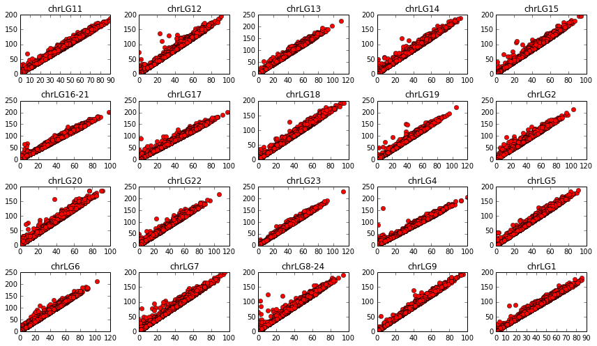

```python
figsize(12,7)

for n,c in enumerate(bigcontigs) :
    subplot(4,5,n)
    title(c)
    plot(mycontigs[c]['df'],mycontigs[c]['dxy'],'ro')
tight_layout()

savefig( 'mweru_df_vs_dxy.png', format='png', dpi=100 )
savefig( 'mweru_df_vs_dxy.pdf', format='pdf', dpi=100 )
```

### Step 10 : write the results

Create a tab delimited text file of $d_f$ and $d_{xy}$ for further analysis in R.

```python
#f = open( 'victoria_df_dxy.tsv', 'w' )
#f = open( 'kivu_df_dxy.tsv', 'w' )
f = open( 'mweru_df_dxy.tsv', 'w' )

f.write('\t'.join(['chr', 'start', 'stop', 'df', 'dxy']) + '\n')
for n,contig in enumerate(mycontigs.keys()) :
    length = contig_lengths[contig]
    for i in range(len(mycontigs[contig]['df'])) :
        #if i == 10 : break
        if (i+1)*block_size > length :
            j = length
        else :
            j = (i+1) * block_size + 1
        f.write( '\t'.join(map(str, [ contig, i*block_size, j, mycontigs[contig]['df'][i], mycontigs[contig]['dxy'][i] ])) + '\n' )
f.close()
```

### Step 11 : calculate per-block read coverage

Calculate the per-block read coverage. The `samtools depth` utility omits zero-coverage sites, so we have to loop over the `.depth` files and accumulate the counts for our blocks.

```python
depth = {}
for contig in bigcontigs :
    depth[contig] = { 'depth' : zeros(contig_lengths[contig]/block_size+1),
                      'nogap' : zeros(contig_lengths[contig]/block_size+1) }
for j,line in enumerate(open( '/home/russell/fish/talapia/78584.depth' )) :
    if j%1000000 == 0 : print j
    contig, i, n = line.strip().split()
    if not bigcontigs.__contains__(contig) : continue
    i,n = (int(i),int(n))
    depth[contig]['depth'][i/block_size] = depth[contig]['depth'][i/block_size] + n
    depth[contig]['nogap'][i/block_size] = depth[contig]['nogap'][i/block_size] + 1
```

[output not shown]

[output cut: 622 more lines]

[output not shown]

### Step 12 : checkpoint

```python
import pickle

pickle.dump( depth, open( '78584.depth.pickle', 'w') )
```

```python
#s0 = pickle.load( open('64253.depth.pickle') )
#s1 = pickle.load( open('64571.depth.pickle') )
s0 = pickle.load( open('78357.depth.pickle') )
s1 = pickle.load( open('78584.depth.pickle') )
```

### Step 13 : write depth data

Create a tab delimited text file of the total coverage for each block.

```python
#f = open( '78357_vs_78584_depth.tsv', 'w' )
f = open( 'checkmate_vs_80344_depth.tsv', 'w' )
f.write( '\t'.join( ['contig', 'start', 'stop', 'checkmate_cov', 'checkmate_nogaps', '80344_cov', '80344_nogaps' ]) + '\n' )
for n,contig in enumerate(mycontigs.keys()) :
    length = contig_lengths[contig]
    for i in range(len(s0[contig]['depth'])) :
        #if i == 10 : break
        if (i+1)*block_size > length :
            j = length
        else :
            j = (i+1) * block_size + 1
        f.write( '\t'.join(map(str, [ contig, i*block_size, j, s0[contig]['depth'][i], s0[contig]['nogap'][i], s1[contig]['depth'][i], s1[contig]['nogap'][i] ])) + '\n' )
f.close()
```

### Continue to R notebook...